# Draft Project

2022-11-02

### Coronary Heart Disease and Stroke

```r
#all_data = read_excel("heart_disease_data.xlsx", sheet = 1)
all_data = read_csv("data.csv")
all_data
```

```
## # A tibble: 1,048,575 × 21
##     Year LocationA…¹ Locat…² Geogr…³ DataS…⁴ Class Topic Data_…⁵ Data_…⁶ Data_…⁷
##    <dbl> <chr>       <chr>   <chr>   <chr>   <chr> <chr>   <dbl> <chr>   <chr>
##  1  1999 AL          Autauga County  NVSS    Card… All …      NA per 10… Age-St…
##  2  2013 AL          Autauga County  NVSS    Card… All …      NA per 10… Age-St…
##  3  2014 AL          Autauga County  NVSS    Card… All …      NA per 10… Age-St…
##  4  2005 AL          Autauga County  NVSS    Card… All …      NA per 10… Age-St…
##  5  2012 AL          Autauga County  NVSS    Card… All …      NA per 10… Age-St…
##  6  2010 AL          Autauga County  NVSS    Card… All …      NA per 10… Age-St…
##  7  2009 AL          Autauga County  NVSS    Card… All …      NA per 10… Age-St…
##  8  2011 AL          Autauga County  NVSS    Card… All …      NA per 10… Age-St…
##  9  2007 AL          Autauga County  NVSS    Card… All …      NA per 10… Age-St…
## 10  2019 AL          Autauga County  NVSS    Card… All …      NA per 10… Age-St…
## # … with 1,048,565 more rows, 11 more variables:
## #   Data_Value_Footnote_Symbol <chr>, Data_Value_Footnote <chr>,
## #   Confidence_limit_Low <dbl>, Confidence_limit_High <dbl>,
## #   StratificationCategory1 <chr>, Stratification1 <chr>,
## #   StratificationCategory2 <chr>, Stratification2 <chr>,
## #   StratificationCategory3 <chr>, Stratification3 <chr>, LocationID <dbl>, and
## #   abbreviated variable names ¹LocationAbbr, ²LocationDesc, …
```

```r
##Cleaning Data
data = all_data %>%
  select(Year,LocationAbbr, LocationDesc, Topic, Data_Value, Stratification1, Stratification2, Stratification3) %>%
  rename(year = Year, state = LocationAbbr, county = LocationDesc, age_group = Stratification1, data = Data_Value, type = Topic, race = Stratification2, sex = Stratification3) %>%
  filter(!is.na(data)) %>%
  arrange(year) %>%
  mutate( type = recode(type, "Coronary heart disease (CHD)" = "CHD", "All stroke" = "Stroke"))
data
```

```
## # A tibble: 677,490 × 8
##     year state county  type                          data age_group  race  sex
##    <dbl> <chr> <chr>   <chr>                        <dbl> <chr>      <chr> <chr>
##  1  1999 AL    Autauga All heart disease            156.  Ages 35-6… Over… Over…
##  2  1999 AL    Autauga Stroke                        26   Ages 35-6… Over… Over…
##  3  1999 AL    Autauga CHD                           98   Ages 35-6… Over… Over…
##  4  1999 AL    Autauga Cardiovascular disease (CVD) 192.  Ages 35-6… Over… Over…
##  5  1999 AL    Autauga Heart failure                 27.5 Ages 35-6… Over… Over…
##  6  1999 AL    Autauga All heart disease             96.7 Ages 35-6… Over… Women
##  7  1999 AL    Autauga Stroke                        22.6 Ages 35-6… Over… Women
##  8  1999 AL    Autauga CHD                           50.6 Ages 35-6… Over… Women
##  9  1999 AL    Autauga Cardiovascular disease (CVD) 121.  Ages 35-6… Over… Women
## 10  1999 AL    Autauga Heart failure                 19.4 Ages 35-6… Over… Women
## # … with 677,480 more rows
```

# Introduction

# Background

Our question is whether age, race, and gender influence stroke and heart disease mortality, and whether geographical location influences the prevalence of these cardiovascular diseases.

Coronary heart disease is the leading cause of death in the United States for both men and women of all racial and ethnic groups, and a stroke occurs every 40 seconds. As a result, analyzing cardiovascular disease is common for many Americans and can affect anyone. Many organizations study and research both the effects and the causes in order to prevent the impact on society from continuing, but there is a general lack of funding for many health research facilities. The Division for Heart Disease and Stroke Prevention, Million Hearts, and WISEWOMEN are a few of these organizations.

Cardiovascular disease encompasses a wide range of heart conditions such as coronary artery disease, heart attack, arrhythmia, heart failure, high blood pressure, and others. Many of the symptoms of heart disease are not noticed by the patient until a major event occurs. Diabetes, obesity, an unhealthy diet, and lack of physical activity all increase one’s risk of heart disease, but it can also be inherited.

Our project will use the provided data to examine the relationships between stroke and coronary heart disease, as well as patient characteristics and geographic location. This data set was collected by the National Vital Statistics System, a division of the Centers for Disease Control and Prevention, and can be found directly on the [CDC website](https://chronicdata.cdc.gov/Heart-Disease-Stroke-Prevention/Rates-and-Trends-in-Heart-Disease-and-Stroke-Morta/7b9s-s8ck). This Federal Government agency obtains its information from state medical records. The data set includes population estimates of stroke and coronary heart disease mortality rates from 1999 to 2019. The data set used a Bayesian spatiotemporal model that was smoothed over time, space, and age group to collect death rate trends.

Cites: https://www.cdc.gov/stroke/facts.htm#:~:text=Stroke%20statistics,-In%202020%2C%201&text=Every%2040%20seconds%2C%20someone%20in,minutes%2C%20someone%20dies%20of%20stroke.&text=Every%20year%2C%20more%20than%20795%2C000,are%20first%20or%20new%20strokes. https://www.cdc.gov/heartdisease/facts.htm https://www.cdc.gov/heartdisease/about.htm

# Analysis

## Age

```r
age_data= data %>%
  filter(type != "Heart failure" & type !=  "Cardiovascular disease (CVD)" & type != "All heart disease") %>%
  filter(race == "Overall", (sex == "Overall")) %>%
  select(year, state, county, type, data, age_group)
age_data
```

```
## # A tibble: 51,300 × 6
##     year state county  type     data age_group
##    <dbl> <chr> <chr>   <chr>   <dbl> <chr>
##  1  1999 AL    Autauga Stroke   26   Ages 35-64 years
##  2  1999 AL    Autauga CHD      98   Ages 35-64 years
##  3  1999 AL    Autauga Stroke  532.  Ages 65 years and older
##  4  1999 AL    Autauga CHD    1066.  Ages 65 years and older
##  5  1999 AL    Baldwin Stroke   21   Ages 35-64 years
##  6  1999 AL    Baldwin CHD      79.5 Ages 35-64 years
##  7  1999 AL    Baldwin Stroke  420.  Ages 65 years and older
##  8  1999 AL    Baldwin CHD    1016.  Ages 65 years and older
##  9  1999 AL    Barbour Stroke   29.3 Ages 35-64 years
## 10  1999 AL    Barbour CHD      65.7 Ages 35-64 years
## # … with 51,290 more rows
```

```r
age_sum = age_data %>%
  group_by(age_group, year, type) %>%
  mutate(c = n(),
         n = c*100000,
    total = sum(data)) %>%
  distinct(total, c,n) %>%
  mutate(p = total/n)
age_sum
```

```
## # A tibble: 84 × 7
## # Groups:   age_group, year, type [84]
##     year type   age_group                   c        n   total        p
##    <dbl> <chr>  <chr>                   <int>    <dbl>   <dbl>    <dbl>
##  1  1999 Stroke Ages 35-64 years          615 61500000  14785. 0.000240
##  2  1999 CHD    Ages 35-64 years          615 61500000  60029. 0.000976
##  3  1999 Stroke Ages 65 years and older   605 60500000 293280. 0.00485
##  4  1999 CHD    Ages 65 years and older   605 60500000 704450. 0.0116
##  5  2000 Stroke Ages 35-64 years          615 61500000  15005. 0.000244
##  6  2000 CHD    Ages 35-64 years          615 61500000  58273. 0.000948
##  7  2000 Stroke Ages 65 years and older   605 60500000 289518. 0.00479
##  8  2000 CHD    Ages 65 years and older   605 60500000 679008. 0.0112
##  9  2001 Stroke Ages 35-64 years          615 61500000  14367. 0.000234
## 10  2001 CHD    Ages 35-64 years          615 61500000  56668  0.000921
## # … with 74 more rows
```

```r
pivot_age = age_sum %>% pivot_wider(names_from = type, values_from = c(c, total, n, p)) %>% rename(
  n_heart = "n_CHD",
  p_heart = "p_CHD",
  p_stroke = "p_Stroke",
  n_stroke = "n_Stroke",
  c_stroke = "c_Stroke",
  c_heart = "c_CHD",
  total_stroke = "total_Stroke",
  total_heart = "total_CHD"
)
pivot_age
```

```
## # A tibble: 42 × 10
## # Groups:   age_group, year [42]
##     year age_g…¹ c_str…² c_heart total…³ total…⁴ n_str…⁵ n_heart p_str…⁶ p_heart
##    <dbl> <chr>     <int>   <int>   <dbl>   <dbl>   <dbl>   <dbl>   <dbl>   <dbl>
##  1  1999 Ages 3…     615     615  14785.  60029.  6.15e7  6.15e7 2.40e-4 9.76e-4
##  2  1999 Ages 6…     605     605 293280. 704450.  6.05e7  6.05e7 4.85e-3 1.16e-2
##  3  2000 Ages 3…     615     615  15005.  58273.  6.15e7  6.15e7 2.44e-4 9.48e-4
##  4  2000 Ages 6…     605     605 289518. 679008.  6.05e7  6.05e7 4.79e-3 1.12e-2
##  5  2001 Ages 3…     615     615  14367.  56668   6.15e7  6.15e7 2.34e-4 9.21e-4
##  6  2001 Ages 6…     605     605 280733. 655548.  6.05e7  6.05e7 4.64e-3 1.08e-2
##  7  2002 Ages 3…     615     615  14141.  56950.  6.15e7  6.15e7 2.30e-4 9.26e-4
##  8  2002 Ages 6…     605     605 274533. 643786.  6.05e7  6.05e7 4.54e-3 1.06e-2
##  9  2003 Ages 3…     615     615  13965.  54304.  6.15e7  6.15e7 2.27e-4 8.83e-4
## 10  2003 Ages 6…     605     605 265880. 618187.  6.05e7  6.05e7 4.39e-3 1.02e-2
## # … with 32 more rows, and abbreviated variable names ¹age_group, ²c_stroke,
## #   ³total_stroke, ⁴total_heart, ⁵n_stroke, ⁶p_stroke
```

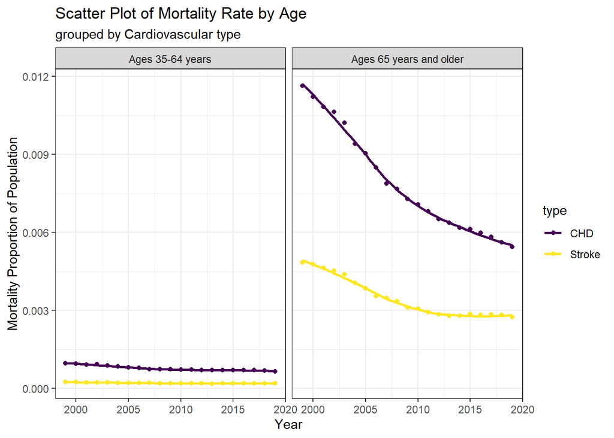

```r
ggplot(age_sum, aes(x = year, y = p, color = type, scale= TRUE))+
  geom_point()+
  geom_smooth(se= FALSE)+
  facet_wrap(~age_group)+
  theme_bw()+
  ggtitle("Scatter Plot of Mortality Rate by Age", subtitle = "grouped by Cardiovascular type")+
  ylab("Mortality Proportion of Population")+
  xlab("Year")
```

### Coronary Heart Disease Hypothesis Tests:

- We will assume that there is a universal parameters $\mu_{\text{35-64}}$ and $\mu_{\text{65+}}$ representing the mean of mortality due to coronary heart disease per year under the experimental conditions aged 35 - 64 and those aged 65 and older, respectively.
- Assume the distribution of the mean of mortality due to coronary heart disease is approximately normal (We are interested in the sampling distribution of the sample)
- Assume that all trials are independent.

Model:

$X_i \sim F_1(\mu_{\text{35-64}}, \sigma_{\text{35-64}}), \quad i = 1, \ldots, n_1$  
$Y_i \sim F_2(\mu_{\text{65+}}, \sigma_{\text{65+}}), \quad i = 1, \ldots, n_2$

Hypotheses:

$H_0: \mu_{\text{35-64}} = \mu_{\text{65+}}$  
$H_a: \mu_{\text{35-64}} \neq \mu_{\text{65+}}$

Test statistic:

$t = \frac{\bar{x} - \bar{y}}{\text{SE}(\bar{x} - \bar{y})}$

```r
x = age_data %>% filter(type == "CHD" & age_group == "Ages 35-64 years") %>% pull(data)
y = age_data %>% filter(type == "CHD" & age_group != "Ages 35-64 years") %>% pull(data)
t.test(x, y)
```

```
##
##  Welch Two Sample t-test
##
## data:  x and y
## t = -270.64, df = 13037, p-value < 2.2e-16
## alternative hypothesis: true difference in means is not equal to 0
## 95 percent confidence interval:
##  -719.3276 -708.9829
## sample estimates:
## mean of x mean of y
##   77.7262  791.8815
```

There is very strong evidence that the mean mortality rate of those aged 35 to 64 who died from coronary heart disease is smaller than the mean of the mortality rate of those aged 65 and older from heart disease ($p = 2.2e-16$, two-sided t-test, unequal variances).

### Stroke Hypothesis Tests:

- We will assume that there is a universal parameters $\mu_{\text{35-64}}$ and $\mu_{\text{65+}}$ representing the mean of mortality due to stroke per year under the experimental conditions aged 35 - 64 and those aged 65 and older, respectively. Assume the distribution of the mean of mortality due to stroke is approximately normal (We are interested in the sampling distribution of the sample)
- Assume that all trials are independent.

Model:

$X_i \sim F_1(\mu_{\text{35-64}}, \sigma_{\text{35-64}}), \quad i = 1, \ldots, n_1$  
$Y_i \sim F_2(\mu_{\text{65+}}, \sigma_{\text{65+}}), \quad i = 1, \ldots, n_2$

Hypotheses:

$H_0: \mu_{\text{35-64}} = \mu_{\text{65+}}$  
$H_a: \mu_{\text{35-64}} \neq \mu_{\text{65+}}$

Test statistic

$t = \frac{\bar{x} - \bar{y}}{\text{SE}(\bar{x} - \bar{y})}$

```r
x = age_data %>% filter(type == "Stroke" & age_group == "Ages 35-64 years") %>% pull(data)
xy = age_data %>% filter(type == "Stroke" & age_group != "Ages 35-64 years") %>% pull(data)
t.test(x, y)
```

```
##
##  Welch Two Sample t-test
##
## data:  x and y
## t = -293.92, df = 12741, p-value < 2.2e-16
## alternative hypothesis: true difference in means is not equal to 0
## 95 percent confidence interval:
##  -776.2712 -765.9860
## sample estimates:
## mean of x mean of y
##  20.75289 791.88145
```

There is very strong evidence that the mean mortality rate of those aged 35 to 64 who died from stroke is smaller than the mean of the mortality rate of those aged 65 and older from heart disease ($p = 2.2e-16$, two-sided t-test, unequal variances).

### Age Influence on Heart Disease vs. Stroke:

```r
age_data %>%
  group_by(type, age_group) %>%
  summarize(mean = mean(data),
            q10 = quantile(data, 0.10),
            q25 = quantile(data, 0.25),
            q50 = quantile(data, 0.5),
            q75 = quantile(data, 0.75),
            q90 = quantile(data, 0.9))
```

```
## # A tibble: 4 × 8
## # Groups:   type [2]
##   type   age_group                mean   q10   q25   q50   q75    q90
##   <chr>  <chr>                   <dbl> <dbl> <dbl> <dbl> <dbl>  <dbl>
## 1 CHD    Ages 35-64 years         77.7  40.7  53.9  71.7  95.6  123.
## 2 CHD    Ages 65 years and older 792.  458.  570.  741.  968.  1197.
## 3 Stroke Ages 35-64 years         20.8  11    13.9  19    26.1   33.2
## 4 Stroke Ages 65 years and older 348.  230.  270.  328.  409.   497.
```

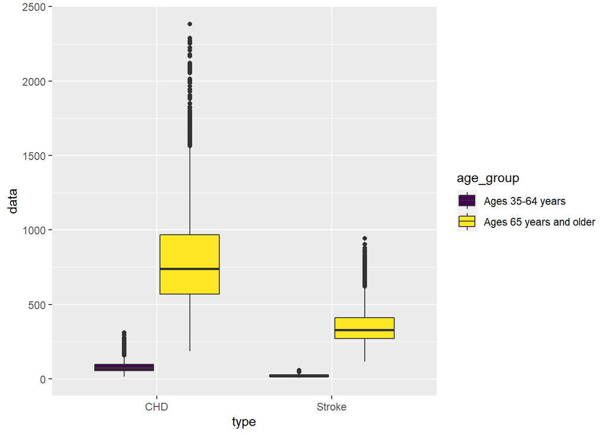

```r
ggplot(age_data, aes(y = data, x = type,  fill = age_group)) +
  geom_boxplot()
```

## Sex

```r
sex_data= data %>%
  filter(type != "Heart failure" & type !=  "Cardiovascular disease (CVD)" & type != "All heart disease", race == "Overall", sex != "Overall") %>%
  select(!race)
sex_data
```

[output not shown]

```r
sex_sum = sex_data %>%
  group_by(sex, year, type) %>%
  mutate(c = n(),
         n = c*100000,
    total = sum(data)) %>%
  distinct(total, c,n) %>%
  mutate(p = total/n)
```

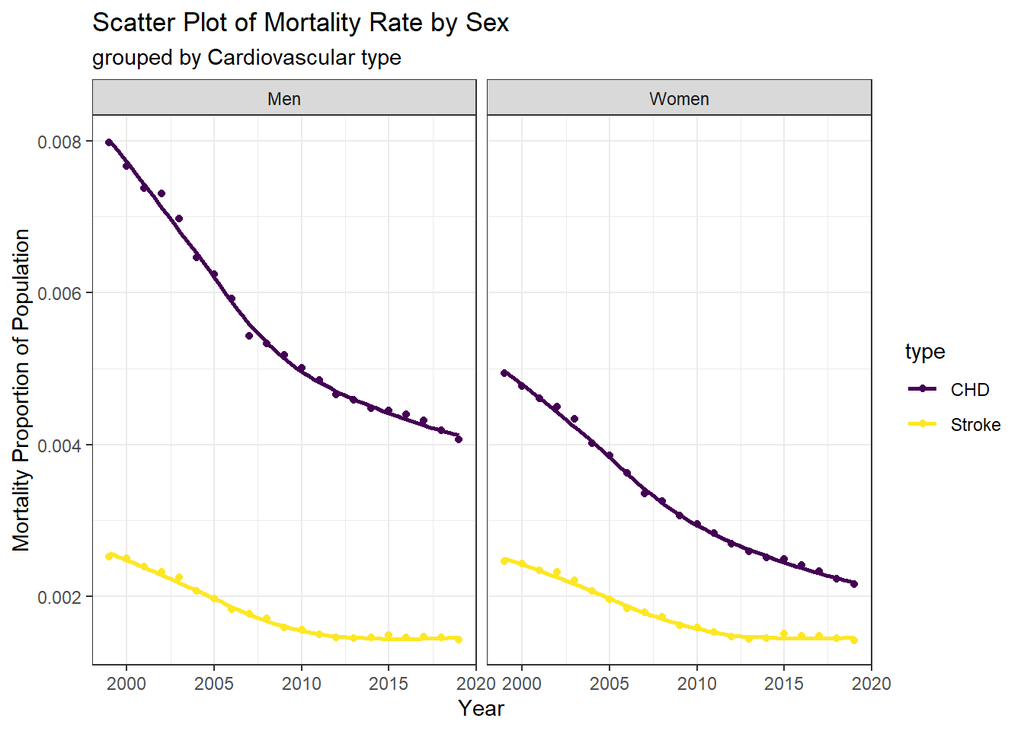

```r
ggplot(sex_sum, aes(x = year, y = p, color = type, scale= TRUE))+
  geom_point()+
  geom_smooth(se= FALSE)+
  facet_wrap(~sex)+
  theme_bw()+
  ggtitle("Scatter Plot of Mortality Rate by Sex", subtitle = "grouped by Cardiovascular type")+
   ylab("Mortality Proportion of Population")+
  xlab("Year")
```

### Coronary Heart Disease Hypothesis Tests:

- We will assume that there is a universal parameters $\mu_{\text{female}}$ and $\mu_{\text{male}}$ representing the mean of female and male mortality due to coronary heart disease per year, respectively.
- Assume that all trials are independent.

Model:

$X_i \sim F_1(\mu_{\text{female}}, \sigma_{\text{female}}), \quad i = 1, \ldots, n_1$  
$Y_i \sim F_2(\mu_{\text{male}}, \sigma_{\text{male}}), \quad i = 1, \ldots, n_2$

Hypotheses:

$H_0: \mu_{\text{female}} = \mu_{\text{male}}$  
$H_a: \mu_{\text{female}} \neq \mu_{\text{male}}$

Test statistic:

$t = \frac{\bar{x} - \bar{y}}{\text{SE}(\bar{x} - \bar{y})}$

```r
x = sex_data %>% filter(type == "CHD" & sex == "Women") %>% pull(data)
y = sex_data %>% filter(type == "CHD" & sex == "Men") %>% pull(data)
t.test(x, y)
```

```
##
##  Welch Two Sample t-test
##
## data:  x and y
## t = -57.121, df = 43777, p-value < 2.2e-16
## alternative hypothesis: true difference in means is not equal to 0
## 95 percent confidence interval:
##  -233.0911 -217.6256
## sample estimates:
## mean of x mean of y
##  330.9610  556.3194
```

*There is very strong evidence that the mean mortality rate of male and female from heart disease(CHD) are different from each other ($p = 2.2e-16$, two-sided t-test, unequal variances).** EDIT

### Stroke Hypothesis Tests:

- We will assume the same assumptions and definition of the $\mu_{\text{female}}$ and $\mu_{\text{male}}$ parameters as the hypothesis above.

Model:

$X_i \sim F_1(\mu_{\text{female}}, \sigma_{\text{female}}), \quad i = 1, \ldots, n_1$  
$Y_i \sim F_2(\mu_{\text{male}}, \sigma_{\text{male}}), \quad i = 1, \ldots, n_2$

Hypotheses:

$H_0: \mu_{\text{female}} = \mu_{\text{male}}$  
$H_a: \mu_{\text{female}} \neq \mu_{\text{male}}$

Test statistic

$t = \frac{\bar{x} - \bar{y}}{\text{SE}(\bar{x} - \bar{y})}$

```r
x = sex_data %>% filter(type == "Stroke" & sex == "Women") %>% pull(data)
y = sex_data %>% filter(type == "Stroke" & sex == "Men") %>% pull(data)
t.test(x, y)
```

```
##
##  Welch Two Sample t-test
##
## data:  x and y
## t = -0.098442, df = 49773, p-value = 0.9216
## alternative hypothesis: true difference in means is not equal to 0
## 95 percent confidence interval:
##  -3.281428  2.967570
## sample estimates:
## mean of x mean of y
##  178.9263  179.0832
```

### Sex Influence on Heart Disease vs. Stroke:

```r
sex_data %>%
  group_by(type, sex) %>%
  summarize(mean = mean(data),
            q10 = quantile(data, 0.10),
            q25 = quantile(data, 0.25),
            q50 = quantile(data, 0.5),
            q75 = quantile(data, 0.75),
            q90 = quantile(data, 0.9))
```

```
## # A tibble: 4 × 8
## # Groups:   type [2]
##   type   sex    mean   q10   q25   q50   q75   q90
##   <chr>  <chr> <dbl> <dbl> <dbl> <dbl> <dbl> <dbl>
## 1 CHD    Men    556.  75   105.  231.   957  1298.
## 2 CHD    Women  331.  23.9  36.6 102.   577.  840.
## 3 Stroke Men    179.  14.5  21.5  49.7  318.  423.
## 4 Stroke Women  179.  11.4  16.3  36    324.  426.
```

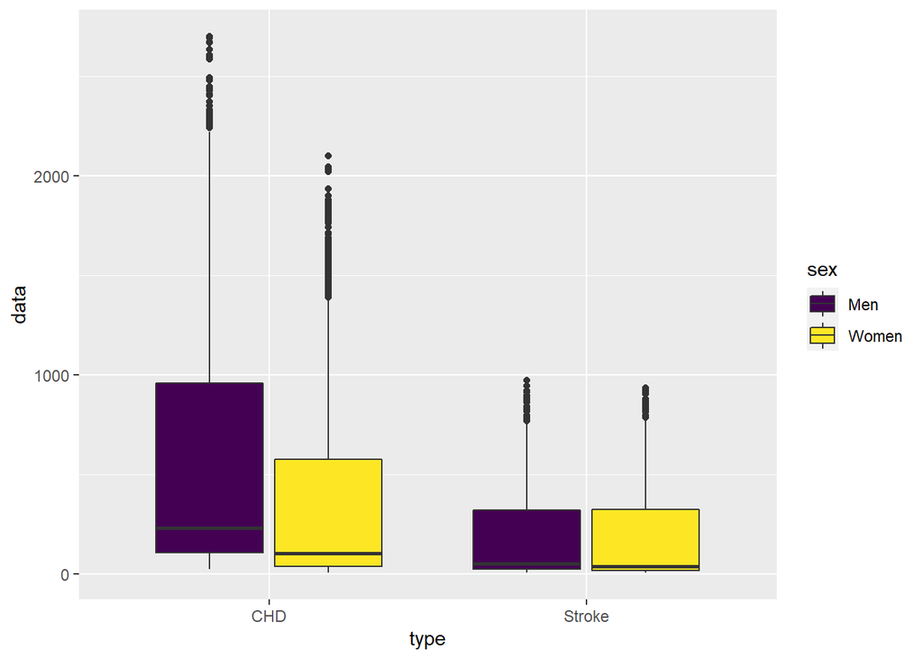

```r
ggplot(sex_data, aes(y = data, x = type,  fill = sex)) +
  geom_boxplot()
```

## Race

```r
race_data= data %>%
  filter(type != "Heart failure" & type !=  "Cardiovascular disease (CVD)" & type != "All heart disease", race != "Overall", sex == "Overall") %>%
  select(!sex)

race_sum = race_data %>%
  group_by(race, year, type) %>%
  mutate(c = n(),
         n = c*100000,
    total = sum(data),
    mean = mean(data)) %>%
  distinct(total, c,n, mean) %>%
  mutate(p = total/n)
race_sum
```

```
## # A tibble: 210 × 8
## # Groups:   race, year, type [210]
##     year type   race                              c       n  total  mean       p
##    <dbl> <chr>  <chr>                         <int>   <dbl>  <dbl> <dbl>   <dbl>
##  1  1999 Stroke Black (Non-Hispanic)            673  6.73e7 1.86e5  277. 0.00277
##  2  1999 CHD    Black (Non-Hispanic)            673  6.73e7 3.94e5  585. 0.00585
##  3  1999 Stroke Hispanic                        516  5.16e7 6.56e4  127. 0.00127
##  4  1999 CHD    Hispanic                        516  5.16e7 1.75e5  340. 0.00340
##  5  1999 Stroke White                          1193  1.19e8 2.90e5  243. 0.00243
##  6  1999 CHD    White                          1193  1.19e8 7.54e5  632. 0.00632
##  7  1999 Stroke American Indian/Alaska Native   170  1.7 e7 2.00e4  118. 0.00118
##  8  1999 CHD    American Indian/Alaska Native   170  1.7 e7 4.50e4  265. 0.00265
##  9  1999 Stroke Asian/Pacific Islander          305  3.05e7 4.61e4  151. 0.00151
## 10  1999 CHD    Asian/Pacific Islander          305  3.05e7 9.31e4  305. 0.00305
## # … with 200 more rows
```

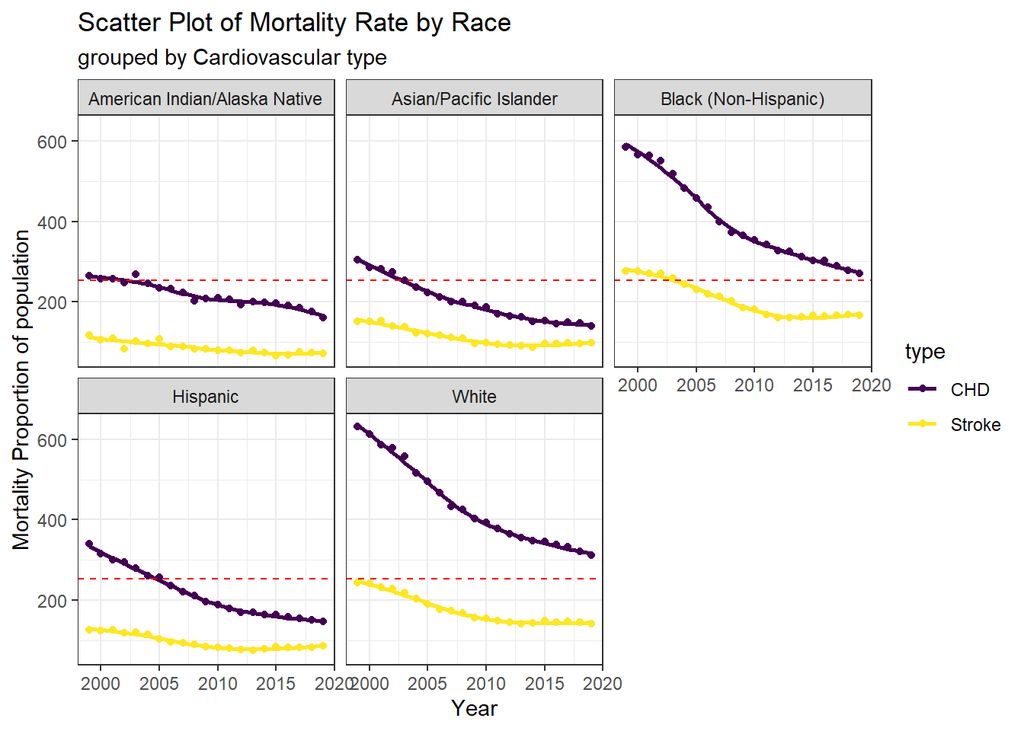

```r
mean= race_data %>% summarize(mean = mean(data)) %>% pull(mean)
ggplot(race_sum, aes(x = year, y = mean, color = type, scale= TRUE))+
  geom_point()+
  geom_smooth(se= FALSE)+
  facet_wrap(~race)+
  theme_bw()+
  geom_hline(yintercept =mean, linetype = "dashed", color = "red")+
  ggtitle("Scatter Plot of Mortality Rate by Race", subtitle = "grouped by Cardiovascular type")+
  ylab("Mortality Proportion of population")+
  xlab("Year")
```

### Coronary Heart Disease Hypothesis Tests:

Model:

$X_i \sim F_1(\mu_{\text{all}}, \sigma_{\text{all}}), \quad i = 1, \ldots, n_1$  
$Y_i \sim F_2(\mu_{\text{black}}, \sigma_{\text{black}}), \quad i = 1, \ldots, n_2$

Hypotheses:

$H_0: \mu_{\text{all}} = \mu_{\text{black}}$  
$H_a: \mu_{\text{all}} \neq \mu_{\text{black}}$

Test statistic:

$t = \frac{\bar{x} - \bar{y}}{\text{SE}(\bar{x} - \bar{y})}$

```r
x = race_data %>% filter(type == "CHD") %>% pull(data)
y = race_data %>% filter(type == "CHD" & race == "Black (Non-Hispanic)") %>% pull(data)
t.test(x, y)
```

```
##
##  Welch Two Sample t-test
##
## data:  x and y
## t = -12.645, df = 20186, p-value < 2.2e-16
## alternative hypothesis: true difference in means is not equal to 0
## 95 percent confidence interval:
##  -56.92401 -41.64480
## sample estimates:
## mean of x mean of y
##  350.5278  399.8122
```

### Stroke Hypothesis Tests:

Model:

$X_i \sim F_1(\mu_{\text{all}}, \sigma_{\text{all}}), \quad i = 1, \ldots, n_1$  
$Y_i \sim F_2(\mu_{\text{asian}}, \sigma_{\text{asian}}), \quad i = 1, \ldots, n_2$

Hypotheses:

$H_0: \mu_{\text{all}} = \mu_{\text{asian}}$  
$H_a: \mu_{\text{all}} \neq \mu_{\text{asian}}$

Test statistic:

$t = \frac{\bar{x} - \bar{y}}{\text{SE}(\bar{x} - \bar{y})}$

```r
x = race_data %>% filter(type == "Stroke") %>% pull(data)
y = race_data %>% filter(type == "Stroke" & race == "Asian/Pacific Islander") %>% pull(data)
t.test(x, y)
```

```
##
##  Welch Two Sample t-test
##
## data:  x and y
## t = 25.305, df = 9268.5, p-value < 2.2e-16
## alternative hypothesis: true difference in means is not equal to 0
## 95 percent confidence interval:
##  40.61329 47.43387
## sample estimates:
## mean of x mean of y
##  156.4580  112.4344
```

### Race Influence on Heart Disease vs. Stroke:

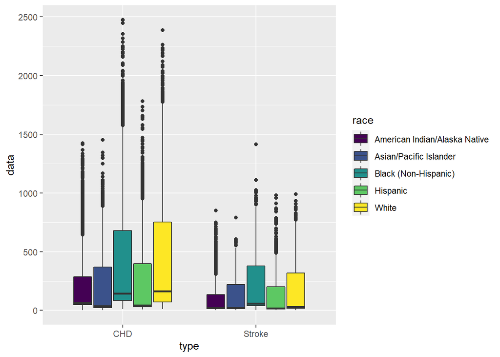

```r
ggplot(race_data, aes(y = data, x = type,  fill = race)) +
  geom_boxplot()
```

# Discussion

```r
dis_data = data %>%
  filter(type != "Heart failure" & type !=  "Cardiovascular disease (CVD)" & type != "All heart disease") %>%
  group_by(year,type, sex, race) %>%
  mutate(c = n(),
         n = c*100000,
    total = sum(data)) %>%
  distinct(total, c, n) %>%
  mutate(p = total/n)
dis_data
```

```
## # A tibble: 336 × 8
## # Groups:   year, type, sex, race [336]
##     year type   race                 sex         c         n   total       p
##    <dbl> <chr>  <chr>                <chr>   <int>     <dbl>   <dbl>   <dbl>
##  1  1999 Stroke Overall              Overall  1220 122000000 308065. 0.00253
##  2  1999 CHD    Overall              Overall  1220 122000000 764479. 0.00627
##  3  1999 Stroke Overall              Women    1185 118500000 291108. 0.00246
##  4  1999 CHD    Overall              Women    1185 118500000 585423. 0.00494
##  5  1999 Stroke Overall              Men      1182 118200000 298264. 0.00252
##  6  1999 CHD    Overall              Men      1182 118200000 943128. 0.00798
##  7  1999 Stroke Black (Non-Hispanic) Overall   673  67300000 186171  0.00277
##  8  1999 CHD    Black (Non-Hispanic) Overall   673  67300000 393827  0.00585
##  9  1999 Stroke Hispanic             Overall   516  51600000  65596. 0.00127
## 10  1999 CHD    Hispanic             Overall   516  51600000 175310. 0.00340
## # … with 326 more rows
```

```r
proportion_stroke = dis_data %>%
  group_by(type) %>%
  summarise(mean_p = mean(p))
proportion_stroke
```

```
## # A tibble: 2 × 2
##   type    mean_p
##   <chr>    <dbl>
## 1 CHD    0.00349
## 2 Stroke 0.00152
```

Beside surveying the mean number of people getting CHD and stroke, we can have some more questions about what is exactly the proportion of getting these diseases. In the following observation, we surveyed whether Black (non-Hispanic) people have higher rate of getting CHD and stroke. The average proportion of getting CHD among sample population in recent decades is 0.0035 and the average proportion of getting Stroke is 0.00152. Use a hypothesis test to test if the average proportion of Black (Non-Hispanic) getting CHD and stroke among sample population in recent decades are equal to 0.0035 and 0.00152 respectively versus the alternative that they are different.

$$H_0: p_{\text{disease of black}} = p_{\text{disease of all}} \\
H_a: p_{\text{disease of black}} > p_{\text{disease of all}}$$

```r
bl_df = dis_data %>%
  filter (race == "Black (Non-Hispanic)")

stroke_df =  bl_df %>% filter(type == "Stroke")
chd_df = bl_df %>% filter(type == "CHD")

x_stroke = stroke_df %>%  pull(p)
x_CHD = chd_df %>%  pull(p)

t.test(x_stroke)
```

```
##
##  One Sample t-test
##
## data:  x_stroke
## t = 21.055, df = 20, p-value = 4.04e-15
## alternative hypothesis: true mean is not equal to 0
## 95 percent confidence interval:
##  0.001851512 0.002258730
## sample estimates:
##   mean of x
## 0.002055121
```

```r
t.test(x_CHD)
```

```
##
##  One Sample t-test
##
## data:  x_CHD
## t = 17.264, df = 20, p-value = 1.755e-13
## alternative hypothesis: true mean is not equal to 0
## 95 percent confidence interval:
##  0.003515034 0.004481209
## sample estimates:
##   mean of x
## 0.003998122
```

```r
blackstroke_sum=  bl_df %>%
  group_by(type) %>%
  summarise(n = n(),
            xbar = mean(p),
            sd = sd(p),
            se = sd / sqrt(n))
blackstroke_sum
```

```
## # A tibble: 2 × 5
##   type       n    xbar       sd        se
##   <chr>  <int>   <dbl>    <dbl>     <dbl>
## 1 CHD       21 0.00400 0.00106  0.000232
## 2 Stroke    21 0.00206 0.000447 0.0000976
```

> We are 95% confident that the mean proportion of Black (Non-hispanic) people getting stroke would have been between 0.001851512 and 0.002258730. We are 95% confident that the mean proportion of Black (Non-hispanic) people getting CHD would have been between 0.003515034 and 0.004481209.

A plot representing the density of proportion of getting these diseases

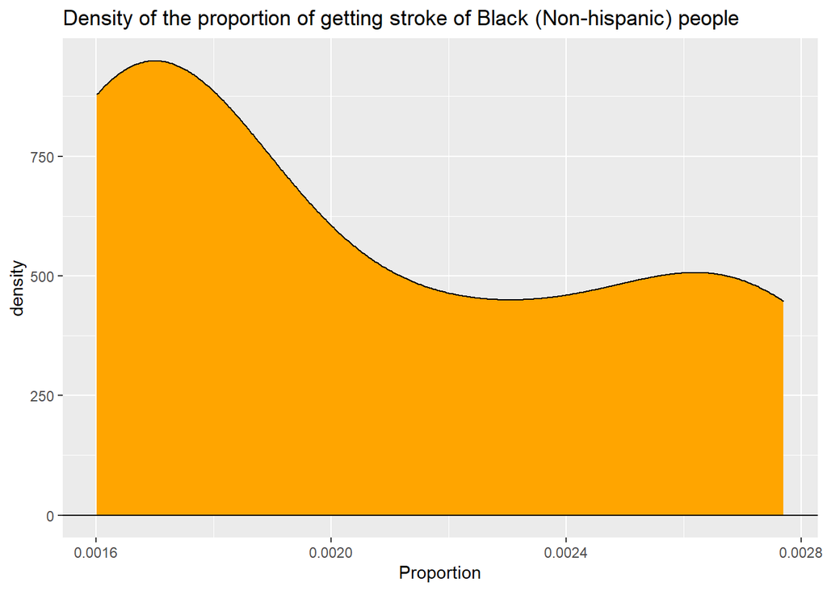

```r
ggplot(stroke_df, aes(x = p))+
  geom_density(fill = 'Orange')+
  ggtitle("Density of the proportion of getting stroke of Black (Non-hispanic) people") +
  xlab("Proportion")+
  geom_hline(yintercept = 0)
```

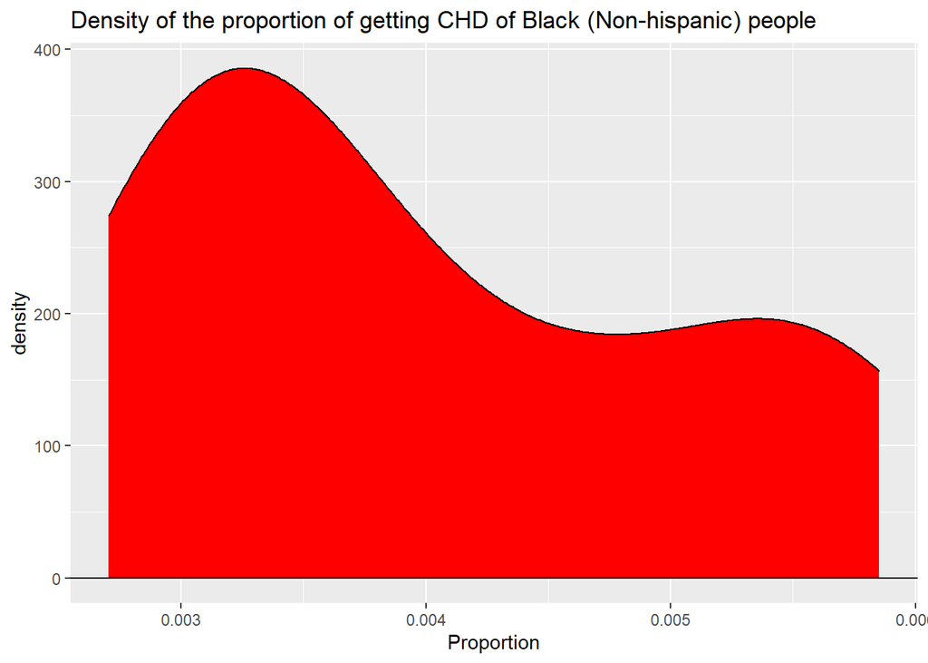

```r
ggplot(chd_df, aes(x = p))+
  geom_density(fill = 'Red') +
  ggtitle("Density of the proportion of getting CHD of Black (Non-hispanic) people")+
  xlab("Proportion")+
  geom_hline(yintercept = 0)
```

```r
mean0_p_stroke = 0.00152
mean0_p_chd = 0.0035
tstat_stroke  = blackstroke_sum %>%
  filter (type == 'Stroke') %>%
  mutate( tstat = (xbar -  mean0_p_stroke)/se,
          pval_stroke = 1- pt(tstat, n-1))
tstat_stroke
```

```
## # A tibble: 1 × 7
##   type       n    xbar       sd        se tstat pval_stroke
##   <chr>  <int>   <dbl>    <dbl>     <dbl> <dbl>       <dbl>
## 1 Stroke    21 0.00206 0.000447 0.0000976  5.48   0.0000115
```

```r
tstat_s = tstat_stroke$tstat

tstat_chd  = blackstroke_sum %>%
  filter (type == 'CHD') %>%
  mutate( tstat = (xbar -  mean0_p_chd)/se,
          pval_stroke = 1- pt(tstat, n-1))
tstat_chd
```

```
## # A tibble: 1 × 7
##   type      n    xbar      sd       se tstat pval_stroke
##   <chr> <int>   <dbl>   <dbl>    <dbl> <dbl>       <dbl>
## 1 CHD      21 0.00400 0.00106 0.000232  2.15      0.0219
```

```r
tstat_c = tstat_chd$tstat
```

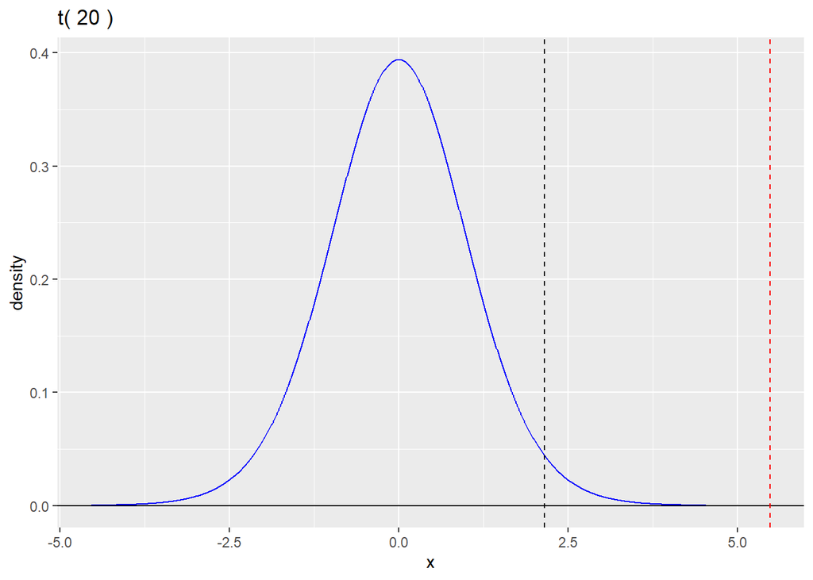

```r
gt(df = 20)+
  geom_vline(xintercept = tstat_s, linetype = "dashed", colour = 'red') +
  geom_vline(xintercept = tstat_c, linetype = "dashed", colour = 'black')
```

In addition, we have the similar questions around the data: whether Asian people have higher proportion of getting diseases than the average of the overall, how much are the proportions, whether they are consistent throughout the years, etc. However, our models might be based on fault assumptions: - The data collected is biased, not random, so we cannot assume these data is random, and making models for the larger population. - The data might not be continuous (There might not be possible the number of people getting disease). - The distribution might not be approximately normal.

For further analyzing, we can dig deeper into factors affecting one group having higher average chance of getting disease (Stroke and CHD), making regression to predict the pattern of the average proportion of people getting disease in different regions , etc.

In conclusion, we devide our result into 3 categories including Age, Sex, and Race: - Age: There is very strong evidence that the mean mortality rate of those aged 35 to 64 who died from coronary heart disease is different from the mean of the mortality rate of those aged 65 and older from heart disease ($p = 2.2e-16$, two-sided t-test, unequal variances). Also, there is very strong evidence that the mean mortality rate of those aged 35 to 64 who died from stroke is different from the mean of the mortality rate of those aged 65 and older from heart disease ($p = 2.2e-16$, two-sided t-test, unequal variances). - Sex: - Race:

# Analysis Summary

# References